# Introduction to R: Data Handling

Ramsy Agha

2020-01-28

# Data handling practice

Ok, you´re done with this long experiment you have been doing over the last weeks and are ready to analyze you precious data. In your experiment, you have been analyzing life history traits of single individual corresponding to four Daphnia genotypes exposed to four different treatments (this is actually a real dataset, see Agha et al. 2016 Sci Reps). For some reason, your data was saved in four separate files, each containing results for each of the treatments.

- The first part of your exercise is to load the indvidual data sets into R.
- The second part is to modify the data sets and merge them with the help of your original identification key to one “master” data set.

*This exercise is meant to introduce you to general ways of working with data in R*

**Before you start**  
Running computational analyses can quickly produce a large number of files with very uninformative names. Therefore, generally, it is a good idea to create specific folders to work in. When you create a new folder, add your data sets to analyse and save an R script for the specific analyses in that folder. In that R script, you can set that folder as working directory with the `setwd()` command. This allows you to load all files in this directory without giving the full path, and it makes sure that all your output files will end up in that same directory, too.

## Load data

Please read the files treatment1.csv, treatment2.csv, treatment3.txt, and treatment4.csv into R.

Getting your data sets into R is the first obstacle you need to overcome. I wanted to give you a realistic example, so all files are a bit different. Make sure you have a look at your imported files to check that they look alright, before you continue. If you have trouble importing the files, you can always open them in a text editor or the terminal to have a look at them. Also, if you are unsure about the syntax or argument of the functions, you can always consult the help dumentation by typing ‘?function’ in the console.

Let’s go through it for each file.

**treatment1.csv**  
Please import as “t1”.  
Hint:

```r
# Use read.csv() Figure out path to file with respect to your working directory
# Have a look at the file, how are the columns separated?
```

Solution:

```r
t1 <- read.csv("Exercise_material/treatment1.csv", header = TRUE, sep = ",")
```

**treatment2.csv**  
Please import as “t2”.  
Hint:

```r
# Have a look at the file, how are the columns separated?
```

Solution:

```r
t2 <- read.csv("Exercise_material/treatment2.csv", header = TRUE, sep = ";")
```

**treatment3.txt**  
Please import as “t3”.  
Hint:

```r
# Ui, this time it's txt file Which character separates the data entries/columns
# in this case?  How do you specify that? Use the help window for 'read.csv()'
```

Solution:

```r
t3 <- read.csv("Exercise_material/treatment3.txt", header = TRUE, sep = "\t")
```

**treatment4.csv**  
Please import as “t4”.

Hint:

```r
# No hints! this one is easy!
```

Solution:

```r
t4 <- read.csv("Exercise_material/treatment4.csv", header = T, sep = ",")
```

## Inspect and modify the data frames

Inspect the data frames. Do they contain all the relevant information? We should have a number of variable in each dataset:

- Treatment,
- *Daphnia* genotype,
- replicate ID,
- age (i.e. age at first reproduction),
- clutch1 (number of offspring at first clutch),
- number of clutches, fecundity (total number of offspring),
- dead (indicates how much of the offspring was found dead),
- lifespan, death (whether the animal died before the end of the experiment or not), -
- 3 sizes (all in micrometers) of mothers, 1st and 3rd clutch.

Hint for looking at the data sets:

```r
# try: str(), dim(), head(), colnames() to view them: type their name or click on
# their name in the 'environment' window (top right)
```

Solutions:

```r
dim(t1)  # 13 columns: ok!
str(t1)  # correct type (integer/numeric)
colnames(t1)
head(t1)  # looks alright
# alternatively, click on the data frame in the top right window in your RStudio
```

Check all data set the same way. What did you find?

```r
# t1: generally ok t2: measured in mm --> we need to convert the last 3 columns
# to um!  t3: seems ok t4: This one looks terrible! The variables were attributed
# wrong classes and NAs sometimes appear #N/A. R wont be able to work with that!
# All data frames have to have the same column names, do they?.
```

Alright, don’t panick. Let’s go one dataset at a time

```r
# create a new column, e.g. size_m assign the new column with the corresponding
# 'old' column multiplied by 1000 to transform the meausrement to micrometers
# check that it worked properly, if necessary, remove superfluous old data
```

Suggestions for solution:

```r
# one by one
t2$size_m <- t2$size_m_mm * 1000
t2$size_c1 <- t2$size_c1_mm * 1000
t2$size_c3 <- t2$size_c3_mm * 1000

# have a look whether it looks correct, then remove the old columns ('_mm')
t2$size_m_mm <- NULL
t2$size_c1_mm <- NULL
t2$size_c3_mm <- NULL


# Bonus options deleting several columns at once: t2[,c('size_m_mm',
# 'size_c1_mm', 'size_c3_mm')] <- list(NULL)

# apply a function across a selection of colums t2.1 <- apply(t2[,c(11:13)], 2,
# function(x) x*1000)


# multiply a selection of columns t2.2 <- t2[,c(1:4)]*1000


# useful: check whether the different methods produce identical data sets
# all(t2.1==t2.2)
```

Ok, lets deal with treatment4: It has some N/As from excel (we all hate Excel now). Lets replace them by NA

Hint

Solution:

```r
t4[t4 == "#N/A"] <- NA
```

Check that everything is okay. Now we have to attribute the correct class to the variables. Selct the individual variable one by one and transform them to the correct class

Hint

```r
t4$age <- as.integer(t4$age)
t4$clutch1 <- as.integer(t4$clutch1)
t4$fecundity <- as.integer(t4$fecundity)
t4$size_m <- as.numeric(t4$size_m)
t4$size_c1 <- as.numeric(t4$size_c1)
t4$size_c3 <- as.numeric(t4$size_c3)
t4$dead <- as.integer(t4$dead)
```

Ok, were set!

Now let’s try to join the four datasets together into a master dataset containing all four treatments.

Hint:

```r
# to stack the data sets by rows, use bind_rows() or rbind()
```

Solution:

```r
library(tidyverse)
master <- bind_rows(list(t1, t2, t3, t4))
```

Tadaaa! Congratulations, well done!

## Data manipulation - The `apply` family functions

Oftentimes, you want to summarize or process your data, for example to produce summary statistics from raw measurements, such as means, standard deviations, etc.

This can be easily done in R. In particular, using a set of functions known as the `apply` funtion family. We call it a family because its a group of similar functions the do almost the same but each of them is applied depending on what type of object we want as input and output. This may sound a bit confusing; let us leave that aside for a moment and focus on how these functions work. To manipulate data, the `apply` functions use a strategy called *Split, Apply, Combine*. The picture below tries to illustrate this with a very easy example:

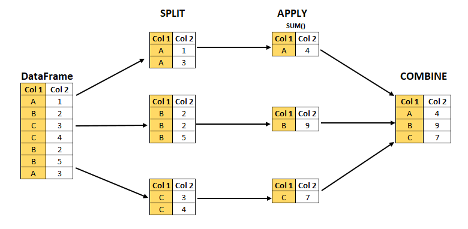

image info

One last thing: You might have noted that I used the term R object in the last paragraph. This is because these functions work on a number of class or types of data that a commonly used in R. You will be mostly using dataframes, but other objects, such as lists, vectors, matrix, etc. are not uncommon. Depending what type of data you want to Split (i.e. input object), and what type of object you want the processed data to Combined into (i.e. output) you will need to use one apply function or another. See the table below for a summary:

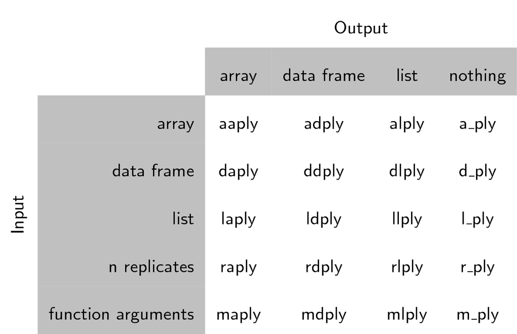

image info

You dont need to remenber this, theres is a trick to remember this :)

## Let’s try it out

The apply functions are contained within the `plyr` package. Make sure you have it installed and loaded

```r
library(plyr)
```

Ready?

The first letter of the function name gives the input type and the second gives the output type. .data - gives the data object to be processed .variables - identifies the splitting variables .fun - gives the function to be called on each piece

```r
# ddply(master, treatment, mean)
```

Just a small reminder: It is important for you to remember that R provide many different the possibility of doing the same things in different ways; what we just went through is one way of doing things, but feel free to explore and learn more. There is plenty of materials and information online. Google is your friend. That´s how we all learnt adn continue doing so!

Now for the last part, visualising and understanding your data. We’ll use ggplot2, which is part of the tidyverse.